# README

# R Assignment

## Part 1: File Inspection

To inspect files, I first read the files into R using the following:

```r
fang <- read.table(file="working_files/fang_et_al_genotypes.txt", sep = "\t", header = TRUE, na.strings="?/?", stringsAsFactors = FALSE)
snps <- read.table(file="working_files/snp_position.txt",sep = "\t", header=TRUE, na.strings = "?/?", stringsAsFactors = FALSE )
```

After some fooling around in the help menu for read.table, I realized that the seperator needed to be specified because the files are not seperated by commas. The default behavior of reading strings as factors would cause issues as well, and I assigned the unknown values from the initial file (?/?) to be NAs using na.strings. Then, I used the following commands to inspect the data:

```r
str(fang)
```

```
## 'data.frame':    2782 obs. of  986 variables:
##  $ Sample_ID     : chr  "SL-15" "SL-16" "SL-11" "SL-12" ...
##  $ JG_OTU        : chr  "T-aust-1" "T-aust-2" "T-brav-1" "T-brav-2" ...
##  $ Group         : chr  "TRIPS" "TRIPS" "TRIPS" "TRIPS" ...
##  $ abph1.20      : chr  NA NA NA NA ...
##  $ abph1.22      : chr  NA NA NA NA ...
##  $ ae1.3         : chr  "T/T" "T/T" "T/T" "T/T" ...
##  $ ae1.4         : chr  "G/G" NA "G/G" "G/G" ...
##  $ ae1.5         : chr  "T/T" "T/T" "T/T" "T/T" ...
##  $ an1.4         : chr  "C/C" "C/C" NA "C/C" ...
##  $ ba1.6         : chr  NA "A/G" "G/G" "G/G" ...
##  $ ba1.9         : chr  "G/G" "G/G" "G/G" "G/G" ...
##  $ bt2.5         : chr  NA NA "C/C" "C/C" ...
##  $ bt2.7         : chr  "A/A" "A/A" "A/A" "A/A" ...
##  $ bt2.8         : chr  NA NA NA NA ...
```

[output cut: 86 more lines]

```r
str(snps)
```

```
## 'data.frame':    983 obs. of  15 variables:
##  $ SNP_ID              : chr  "abph1.20" "abph1.22" "ae1.3" "ae1.4" ...
##  $ cdv_marker_id       : int  5976 5978 6605 6606 6607 5982 3463 3466 5983 5985 ...
##  $ Chromosome          : chr  "2" "2" "5" "5" ...
##  $ Position            : chr  "27403404" "27403892" "167889790" "167889682" ...
##  $ alt_pos             : chr  "" "" "" "" ...
##  $ mult_positions      : chr  "" "" "" "" ...
##  $ amplicon            : chr  "abph1" "abph1" "ae1" "ae1" ...
##  $ cdv_map_feature.name: chr  "AB042260" "AB042260" "ae1" "ae1" ...
##  $ gene                : chr  "abph1" "abph1" "ae1" "ae1" ...
##  $ candidate.random    : chr  "candidate" "candidate" "candidate" "candidate" ...
##  $ Genaissance_daa_id  : int  8393 8394 8395 8396 8397 8398 8399 8400 8401 8402 ...
##  $ Sequenom_daa_id     : int  10474 10475 10477 10478 10479 10481 10482 10483 10486 10487 ...
##  $ count_amplicons     : int  1 0 1 0 0 1 1 0 1 0 ...
##  $ count_cmf           : int  1 0 1 0 0 1 0 0 1 0 ...
##  $ count_gene          : int  1 0 1 0 0 1 1 0 1 0 ...
```

I felt that most of the things that could be covered by other functions are included in the str function, but other options for data inspection are names, dim, typeof, length, most of which are covered under str.

## Data Manipulation

Note: During data manipulation process, I typically used the View command to look at the structure of the data after each step, if possible.

The first step that needs to occur is the removal of the selected genotypes from the overall file to generate two files: One that contains all of the zea mays and one that contains teosinte. I used the dplyr package to filter my data. The first line of code is from lecture, and I used it to determine if my machine had dplyr or not.

```r
if (!require("dplyr")) install.packages("dplyr")
library(dplyr)
maize <- filter(fang, Group == "ZMMIL" | Group == "ZMMLR" | Group == "ZMMMR")
teosinte <- filter(fang, Group == "ZMPBA" | Group == "ZMPIL" | Group == "ZMPJA")
```

The next step is to transpose, so I used:

```r
trans_maize <- t(maize)
trans_teos <- t(teosinte)
```

I saw that the newly transposed objects trans_teos and trans_maize were matrices, and felt the need to convert them to dataframes, which also needs to have the strings as factors turned to false to have manipulatable data.

```r
df_trans_maize <- as.data.frame(trans_maize, stringsAsFactors = FALSE)
df_trans_teos <- as.data.frame(trans_teos, stringsAsFactors = FALSE)
```

This gave me transposed data frames. From here, the data needed to be joined together, using the merge command:

```r
maize_merge <- merge(snps, df_trans_maize, by.x = "SNP_ID", by.y = "row.names")
teos_merge <- merge(snps, df_trans_teos, by.x = "SNP_ID", by.y = "row.names")
```

After the merge, I needed to reorder the columns, so I used:

```r
rearr_maize <- maize_merge[,c(1,3,4,2,5:1588)]
rearr_teos <- teos_merge[,c(1,3,4,2,5:990)]
```

After checking the order with View, I moved to the next step, which was substituting either “-” or “?” for NA. I found a way to do this using is.na, but the command acts on a data frame, and replaces the NAs in that data frame, and cannot be assigned to a new one. So, I used the following:

```r
hyph_maize <- rearr_maize
hyph_maize[is.na(hyph_maize)]<- "-"
ques_maize <- rearr_maize
ques_maize[is.na(ques_maize)] <- "?"
hyph_teos <- rearr_teos
hyph_teos[is.na(hyph_teos)]<- "-"
ques_teos <- rearr_teos
ques_teos[is.na(ques_teos)] <- "?"
```

This generated four files, which needed to be sorted, so I used the arrange command as below:

```r
arr_hyphmaize <- arrange(hyph_maize, desc(Position))
arr_hyphteos <- arrange(hyph_teos, desc(Position))
arr_quesmaize <- arrange(ques_maize, Position)
arr_questeos <- arrange(ques_teos, Position)
```

After sorting the four files, I needed to generate 10 files per each of the four in the previous step, for a total of 40 files. First I split the data by the chromosome column using:

```r
hyphmaize_chr_split <- split(arr_hyphmaize, arr_hyphmaize$Chromosome)
quesmaize_chr_split <- split(arr_quesmaize, arr_quesmaize$Chromosome)
hyphteos_chr_split <- split(arr_hyphteos, arr_hyphteos$Chromosome)
questeos_chr_split <- split(arr_questeos, arr_questeos$Chromosome)
```

Then, I used the function lapply to apply a function to all elements of my list, using a function defined as write.table for each element of the list, and creating files with the prefix of th(teosinte hyphens), tq(teosinte question marks), mh, and mq (maize equivalents).Then, I used followed the prefix with the name “chromosome”, followed by the chromosome number (x):

```r
lapply(names(hyphmaize_chr_split), function(x){write.table(hyphmaize_chr_split[[x]], file = paste("mh_chromosome",x, sep = "\t"))})
```

```r
lapply(names(quesmaize_chr_split), function(x){write.table(quesmaize_chr_split[[x]], file = paste("mq_chromosome",x, sep = "\t"))})
```

```r
lapply(names(hyphteos_chr_split), function(x){write.table(hyphteos_chr_split[[x]], file = paste("th_chromosome",x, sep = "\t"))})
```

```r
lapply(names(questeos_chr_split), function(x){write.table(questeos_chr_split[[x]], file = paste("tq_chromosome",x, sep = "\t"))})
```

After generating these 40 files, I deleted the multiple and unknown position files, and moved the 10 relevant files each to a folder named question_files or hyphenated_files, then further into folders based on genotype.

For the next part of the assignment, ggplots needed to be generated, and it was suggested to use the reshape2 package, so I ran the following to determine if it was installed or not:

```r
if (!require("reshape2")) install.packages("reshape2")
library(reshape2)
```

Once reshape2 was installed and loaded, I usedthe following to make the data tidier:

```r
molten_maize <- melt(rearr_maize)
```

[output not shown]

```r
molten_teos <- melt(rearr_teos)
```

[output not shown]

```r
maize_table <-as.data.frame(table(molten_maize$Chromosome))
colnames(maize_table)[1] <- "Maize_Chrom_Number"
teos_table <-as.data.frame(table(molten_teos$Chromosome))
colnames(teos_table)[1]<- "Teos_Chrom_Number"
```

```r
if (!require("ggplot2")) install.packages("ggplot2")
library(ggplot2)
```

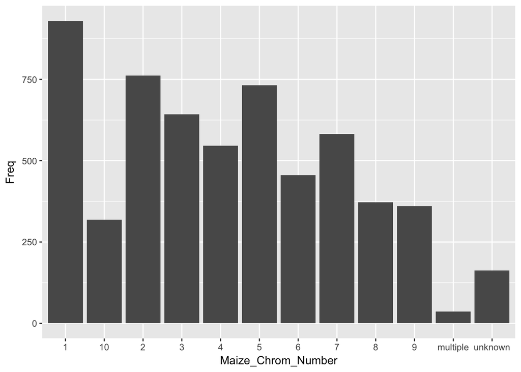

```r
ggplot(maize_table)+geom_col(aes(x=Maize_Chrom_Number, y=Freq))
```

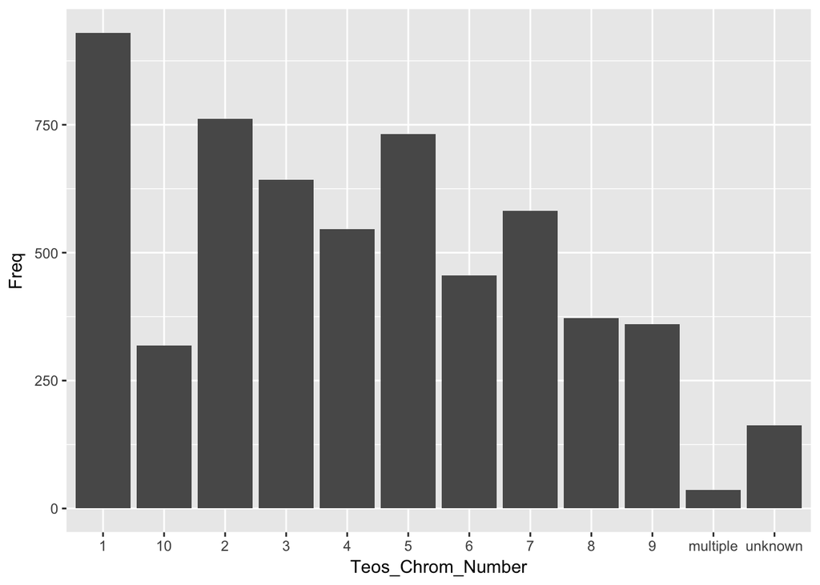

```r
ggplot(teos_table)+geom_col(aes(x=Teos_Chrom_Number, y=Freq))
```